# Instituto Técnico Superior

[figure not shown]

# **¡Bienvenido/a al Instituto Técnico Superior Gauss Kish!**

**Misión**

Perfeccionar la formación de recursos humanos, su interacción con la  
estadística, las herramientas informáticas, la producción de  
conocimientos relativos al ámbito productivo, de servicios, mediante la  
investigación en el más amplio marco de libertad académica y  
participación plural.

**Visión**

Ser una Institución referente en la formación de técnicos con capacidad  
de investigación y análisis de la realidad productiva y de servicios,  
con avanzado conocimiento de métodos y herramientas de planeamiento,  
asesoramiento, dirección, coordinación, ejecución, evaluación y de  
informáticas.

**Novedades**

- [**CURSOS 2024 disponibles!!! click aquí**](https://gausskish.github.io/cursos/#cursos)
- [**TALLERES GRATUITOS 2024!!! click aquí**](https://gausskish.github.io/cursos/#talleres)

**Metodología Online**

El curso se lleva a cabo de manera completamente virtual en línea a  
través de la plataforma ZOOM, lo que facilita que tanto los  
participantes como los docentes aprovechen las características de esta  
plataforma. Las clases se graban y se envían a los participantes, y el  
material del curso se gestionará a través del Campus Virtual de IGK.  
Nuestro enfoque educativo es sincrónico, lo que significa que el docente  
y el participante pueden escucharse, leerse y/o verse en tiempo real,  
incluso si se encuentran en ubicaciones físicas diferentes. Esto permite  
una interacción instantánea durante el curso.

# **CURSOS**

[figure not shown]

**Power BI desde Principiante a Avanzado**

**Descripción:** Microsoft Power BI es una solución de creación de informes completa que ofrece preparación de datos, visualización de datos, distribución y administración a través de herramientas de desarrollo y una plataforma en línea.

Power BI puede escalar desde informes simples mediante un único origen de datos a informes que requieren modelos de datos complejos y temas coherentes. Use Power BI para crear informes visualmente impresionantes e interactivos que sirvan como motor de análisis y toma de decisiones para proyectos de grupo, divisiones u organizaciones enteras.

Power BI es una herramienta esencial para los analistas de datos y su organización; sin embargo, todos los profesionales de datos sacan provecho de comprender cómo funciona Power BI para explorar y presentar información de datos dentro de las organizaciones.

**Modalidad:** Virtual

**Días:**Jueves de 19 a 21 hs.

**Inicio:Nivel Principiante:** 04, 11 y 18 de abril de 2024

**Inicio: Nivel Intermedio:** 25 de abril, 02 y 09 de mayo de 2024

**Plataforma:** [Moodle IGK](https://formaciongaussvirtual.edu.py/)

**Contenido detallado:** [Click aquí](https://drive.google.com/file/d/1q1Y0xxS4U1WWHOCzR7LKoHnMTPu6q4E5/view?usp=sharing)

**¡Regístrate aquí para el curso! [Click aquí para registrarse al curso](https://forms.gle/udY8AhgKmJSeuzcf9)**

**Sumate al grupo de WhatsApp del curso:** [Click aquí](https://chat.whatsapp.com/JRyBb6Ta3S6LOV33kuX8q3)

[figure not shown]

**Estadística: “Formularios Inteligentes con Google: Estrategias para Recopilar Datos de Forma Eficiente”**

**Descripción:** Google forms Es una herramienta en línea proporcionada por Google que permite a los usuarios crear encuestas, cuestionarios y formularios personalizados de manera fácil y gratuita. Los usuarios pueden diseñar preguntas de varios tipos, como preguntas de opción múltiple, respuestas cortas, preguntas de respuesta larga, escalas de calificación y más. Una vez que se crea el formulario, se puede compartir fácilmente con otros a través de un enlace o incrustarlo en una página web.

**Modalidad:** Virtual

**Días:**Martes de 19 a 21 hs.

**Inicio:Nivel Principiante:** 07, 21, 28 de mayo y 04 de junio de 2024

**Plataforma:** [Moodle IGK](https://formaciongaussvirtual.edu.py/)

**Contenido detallado:** [Click aquí](https://arandurapeedu-my.sharepoint.com/:b:/g/personal/gonzalezfrutos_mec_edu_py/EXYQenFuPKVKt1D_MQcjQ80B01uojKzlbM5iLDbzoEjHsw?e=DlGfSI)

**¡Regístrate aquí para el curso! [Click aquí para registrarse al curso](https://forms.gle/9xoY4kK7DA3HNQKF9)**

**Sumate al grupo de WhatsApp del curso:** [Click aquí](https://chat.whatsapp.com/ClScVxRzrNR0zhCXq2kEkt)

[figure not shown]

**ChatGPT para Docentes**

GPT, o Generative Pre-trained Transformer, es un modelo de lenguaje de inteligencia artificial desarrollado por OpenAI. Se basa en la arquitectura de transformers, que ha demostrado ser efectiva en tareas relacionadas con el procesamiento del lenguaje natural (NLP).

La principal característica de GPT es su capacidad para generar texto coherente y contextual. Este modelo es “preentrenado” en grandes cantidades de datos para aprender patrones lingüísticos y contextuales antes de ser afinado para tareas específicas.

**Duración:** 40 horas

**Modalidad:** Virtual

**Días:** Miércoles desde 19:00 a 21:00 hs.

**Inicio:** 08 de mayo de 2024. (4 clases)

**Plataforma:** [Moodle IGK](https://formaciongaussvirtual.edu.py/)

**Contenido detallado:** [Click aquí](https://arandurapeedu-my.sharepoint.com/:b:/g/personal/gonzalezfrutos_mec_edu_py/EUFoShpGo2xHnuqJnVJiGXUB1xt1jVrJlXMxbM8jf87LeQ?e=cZRIoP)

¡Regístrate aquí! [Click aquí para registrarse al curso](https://forms.gle/BoNDS4TZy3x4vaDcA)

[figure not shown]

**Análisis de Datos con R y ChatGPT**

Aprende a dominar el poder del análisis de datos con R y aprovecha la inteligencia artificial de ChatGPT para llevar tus habilidades al siguiente nivel. Este curso te brindará las herramientas necesarias para convertirte en un experto en análisis de datos y utilizar ChatGPT para obtener información útil y tomar decisiones basadas en datos.

**Duración:** 40 horas

**Modalidad:** Virtual

**Días:** Martes desde 19:00 a 21:00 hs.

**Inicio:** Martes 19 de marzo de 2024.(4 clases)

**Plataforma:** [Moodle IGK](https://formaciongaussvirtual.edu.py/)

**Contenido detallado:** [Click aquí](https://drive.google.com/file/d/1QDJMScwNAR0foGgqXoJs7p-0b9CDuvVU/view?usp=sharing)

**¡No pierdas la oportunidad de aprovechar este curso y llevar tus habilidades de análisis de datos al siguiente nivel! Regístrate ahora y descubre el poder de R y ChatGPT en el análisis de datos.**

¡Regístrate aquí! [Click aquí para registrarse al curso](https://forms.gle/BoNDS4TZy3x4vaDcA)

[figure not shown]

**Documentos Técnicos y Científicos con LaTeX**

**¿Qué es LaTeX?**

LaTeX es un sistema de preparación de documentos de alta calidad y ampliamente utilizado, especialmente en el ámbito académico y científico. A diferencia de procesadores de texto convencionales como Microsoft Word, LaTeX utiliza un enfoque de marcado para la creación de documentos.

**Duración:** 3 meses

**Carga horaria:** 40 horas

**Modalidad:** Virtual

**Plataforma:** [Moodle IGK](https://formaciongaussvirtual.edu.py/)

**Guía del alumno/a:** [Click aquí](https://drive.google.com/file/d/1Vnd1fysNDciDD7feiGZ3vq_GfUA9He4H/view?usp=sharing)

**¡Regístrate aquí! [Click aquí para registrarse al curso](https://forms.gle/i3zo6w3MYjiGNp25A)**

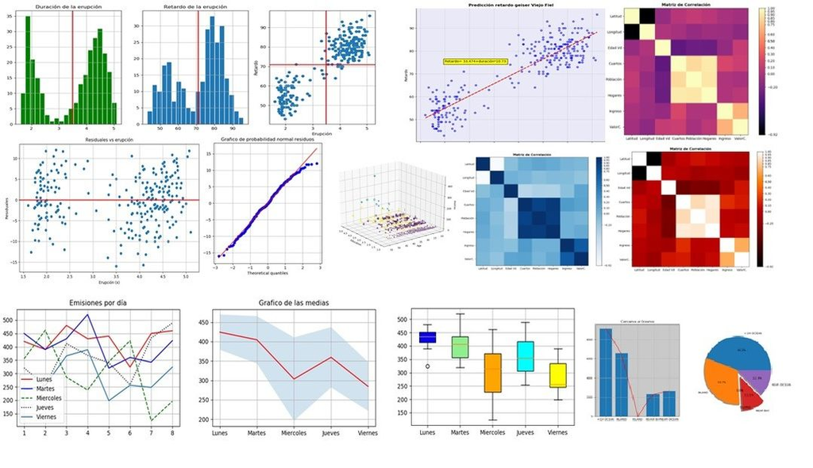

**Curso Estadística Práctica para Ciencia de Datos con R y Python**

**Descripción:** Este curso te proporcionará las habilidades esenciales de estadística práctica necesarias para proyectos de ciencia de datos. Aprenderás a aplicar conceptos estadísticos utilizando R y Python, dos lenguajes fundamentales en el campo de la ciencia de datos.

**Duración:** 40 horas

**Modalidad:** Virtual

**Días:** Sábados desde 09hs. a 12hs. ( 5 clases)

**Inicio:** Sábado 10 de febrero de 2024.

**Plataforma:** [Moodle IGK](https://formaciongaussvirtual.edu.py/)

**Requisitos:** Conocimientos básicos de R y Python serán beneficiosos, pero no obligatorios. ¡Todos son bienvenidos!

**Contenido detallado:** [Click aquí](https://arandurapeedu-my.sharepoint.com/:b:/g/personal/gonzalezfrutos_mec_edu_py/EW5J0BMm7ZpGtU3T6CT3-CMBJilBNlM1h-UeBnaX31jSpg?e=7Zrwnh)

**¡Regístrate aquí hoy y lleva tus habilidades de ciencia de datos al siguiente nivel! [Click aquí para registrarse al curso](https://forms.gle/BzEus81zwnq271VU6)**

**Sumate al grupo de WhatsApp del curso:** [Click aquí](https://chat.whatsapp.com/KWFHEpRvPVEJIjAcUgKS6q)

[figure not shown]

**SPSS. Procesamiento y Análisis**

**Descripción:** ¡Descubre el potencial de SPSS en nuestro curso de Procesamiento y Análisis de Datos! Este programa te proporcionará las habilidades esenciales para utilizar SPSS de manera efectiva en la investigación, la toma de decisiones y mucho más.

**Duración:** 40 horas

**Modalidad:** Virtual

**Días:** Miércoles de 19 a 21 hs.(5 sesiones)

**Inicio:** 21 de febrero de 2024

**Plataforma:** [Moodle IGK](https://formaciongaussvirtual.edu.py/)

**Contenido detallado:** [Click aquí](https://arandurapeedu-my.sharepoint.com/:b:/g/personal/gonzalezfrutos_mec_edu_py/EZXQeWDUhFFFpPA9eziWNkQBaZ6ZsibPV-jFPSmggpMPWA?e=dN66yL)

**¡Regístrate aquí para el curso! [Click aquí para registrarse al curso](https://forms.gle/7p4yB22B2SEQBtYz8)**

# **Talleres Gratuitos 2024**

# **Abril**

**¡Regístrate aquí para los talleres! [Click aquí para registrarse](https://forms.gle/SsuuCdcgcFaw1Vc96)**

**SQL.**

Fecha : 23 y 30 de abril

Hora :19.00 hs:

**Ver video en:** [Youtube Próximamente](https://www.youtube.com/channel/UCHLd8Pt9rjvuZldJhfwEr9w)

**SPSS.**

Fecha : 17 y 24 de abril

Hora :19.00 hs.

**Ver video en:** [Youtube Próximamente](https://www.youtube.com/channel/UCHLd8Pt9rjvuZldJhfwEr9w)

**CANVA.**

Fecha : 18 y 25 de abril

Hora :16.00 hs.

**Ver video en:** [Youtube Próximamente](https://www.youtube.com/channel/UCHLd8Pt9rjvuZldJhfwEr9w)

# **Marzo**

**¡Regístrate aquí para los talleres! [Click aquí para registrarse](https://forms.gle/SsuuCdcgcFaw1Vc96)**

**Estadística básica con Excel.**

Fecha : 23 de marzo y 06 de abril

Hora :09.00 hs:

**Ver video en:** [Youtube Próximamente](https://www.youtube.com/channel/UCHLd8Pt9rjvuZldJhfwEr9w)

**Dashboard Dinámico con Excel.**

Fecha : 12 y 15 de marzo

Hora :19.00 hs.

**Ver video en:** [Youtube Próximamente](https://www.youtube.com/channel/UCHLd8Pt9rjvuZldJhfwEr9w)

# **Talleres Gratuitos 2023**

**CIENCIAS DE DATOS CON PYTHON**

**Ver video en:** [Youtube](https://www.youtube.com/playlist?list=PLiuJzNmvf5jPnCUN56p3NRO_dFH0bd16w)

**POWER POINT**

**Ver video en:** [Youtube](https://www.youtube.com/playlist?list=PLiuJzNmvf5jNGwoKEUPzTbrr6SFy4L2CA)

**SQL**

**Ver video en:** [Youtube](https://www.youtube.com/playlist?list=PLiuJzNmvf5jNqLOvqgZIIqNQOIgPFO_h8)

**POWER BI**

**Ver video en:** [Youtube](https://www.youtube.com/playlist?list=PLiuJzNmvf5jMvcTjDRTW2xuTIt1x6tf_J)

**MUESTREO ESTADÍSTICO**

**Ver video en:** [Youtube](https://www.youtube.com/playlist?list=PLiuJzNmvf5jPMvbOI63kP2HvfJ_vrToTR)

**DASHBOARD CON EXCEL**

**Video:** [Youtube](https://www.youtube.com/playlist?list=PLiuJzNmvf5jP8hjBPtdnyExGsy1OTdryE)

# **DOCENTES**

Profesionales con una amplia experiencia en el ámbito de la estadística, informática, economía, investigación y tecnología informática. Poseen una excelente capacidad para transmitir información mediante una metodología participativa, material didáctico e instrumentos bajo la modalidad Virtual - OnLine a los participantes en los cursos.

# **GALERIA**

**Análisis de Datos y Business Intelligence**

[figure not shown]

[figure not shown]

**Curso Estadística Práctica para Ciencia de Datos con R y Python**

[figure not shown]

# **CONTACTENOS**

**Contacto**

**Teléfono:** +595976526218 [WhatsApp](https://wa.me/message/7UXXXSCNJPQQN1)

**Correo:** gausskish@gmail.com

**YouTube :** [Click aquí](https://www.youtube.com/channel/UCHLd8Pt9rjvuZldJhfwEr9w)

**Facebook:** [Click aquí](https://www.facebook.com/formaciongauss)

[figure not shown]